# Foxp1a & Foxp1b Lipid Droplet Spatial Analysis

Minchin Lab - University of Edinburgh

2026-01-29

# Overview

This analysis examines lipid droplet (LD) diameter in **foxp1a** (ed116) and **foxp1b** (ed125) mutant zebrafish under control and high-fat diet (HFD) conditions using a paired experimental design. The same individual fish were measured under both diet conditions - initial imaging after control diet at 35dpf, followed by 14 days of a high-fat diet (5% chicken egg yolk), then imaging of responses to high-fat diet at 49dpf.

## Experimental Design

| Parameter | Details |
| --- | --- |
| **Design** | Paired - same fish measured under both conditions |
| **Control imaging** | 35 dpf |
| **HFD treatment** | 14 days (5% chicken egg yolk) |
| **HFD imaging** | 49 dpf |
| **Spatial bins** | 200 um strata from oldest (anterior) lipid droplets |
| **Measurement** | Mean Feret diameter per stratum per fish |

## Genotype Key

| Allele | Gene | Mutation Type |
| --- | --- | --- |
| ed116 | foxp1a | Loss-of-function |
| ed125 | foxp1b | Loss-of-function |

# Setup

```r
library(lme4)
library(lmerTest)
library(emmeans)
library(dplyr)
library(ggplot2)
library(tidyr)
library(knitr)
```

```r
# Color schemes
colors_foxp1a <- c("mut_con" = "#99D6D6", "mut_hfd" = "#2B7A78",
                   "wt_con" = "#B0B0B0", "wt_hfd" = "#505050")
colors_foxp1b <- c("mut_con" = "#e2baba", "mut_hfd" = "#CD5C5C",
                   "wt_con" = "#B0B0B0", "wt_hfd" = "#505050")

effect_colors_foxp1a <- c("Diet (Mutant)" = "#2B7A78", "Diet (WT)" = "#505050",
                          "Genotype (Control)" = "#99D6D6", "Genotype (HFD)" = "#B0B0B0")
effect_colors_foxp1b <- c("Diet (Mutant)" = "#CD5C5C", "Diet (WT)" = "#505050",
                          "Genotype (Control)" = "#e2baba", "Genotype (HFD)" = "#B0B0B0")
```

# Load Data

```r
# Load supplementary data (should be in same directory)
data_file <- "foxp1_ld_spatial_data_supplementary.csv"
all_data <- read.csv(data_file)

# Add simplified group column
all_data <- all_data %>%
  mutate(Simplified_Group = case_when(
    Genotype == "Mutant" & Diet == "Control" ~ "mut_con",
    Genotype == "Mutant" & Diet == "HFD" ~ "mut_hfd",
    Genotype == "WT" & Diet == "Control" ~ "wt_con",
    Genotype == "WT" & Diet == "HFD" ~ "wt_hfd"
  ))

# Calculate group averages
group_averages <- all_data %>%
  group_by(Experiment, Simplified_Group, Genotype, Diet, Stratum) %>%
  summarise(
    Group_Mean_Feret = mean(Mean_Feret, na.rm = TRUE),
    Group_SEM_Feret = sd(Mean_Feret, na.rm = TRUE) / sqrt(n()),
    N_Fish = n(),
    .groups = 'drop'
  )
```

## Sample Summary

```r
all_data %>%
  group_by(Experiment, Genotype, Diet) %>%
  summarise(
    N_Fish = n_distinct(Fish_ID),
    N_Strata = n(),
    Total_LDs = sum(Count_LDs),
    .groups = 'drop'
  ) %>%
  kable(caption = "Sample sizes by experiment and group")
```

Sample sizes by experiment and group

| Experiment | Genotype | Diet | N_Fish | N_Strata | Total_LDs |
| --- | --- | --- | --- | --- | --- |
| foxp1a | Mutant | Control | 5 | 66 | 2025 |
| foxp1a | Mutant | HFD | 4 | 58 | 1498 |
| foxp1a | WT | Control | 5 | 58 | 1297 |
| foxp1a | WT | HFD | 5 | 63 | 1667 |
| foxp1b | Mutant | Control | 5 | 44 | 796 |
| foxp1b | Mutant | HFD | 5 | 46 | 1001 |
| foxp1b | WT | Control | 4 | 41 | 951 |
| foxp1b | WT | HFD | 4 | 55 | 1596 |

# Foxp1b (ed125) Analysis

```r
foxp1b_data <- all_data %>% filter(Experiment == "foxp1b")
foxp1b_avg <- group_averages %>% filter(Experiment == "foxp1b")
```

## Sample Sizes

```r
foxp1b_data %>%
  group_by(Genotype, Diet) %>%
  summarise(N_Fish = n_distinct(Fish_Pair), N_Observations = n(), .groups = 'drop') %>%
  kable(caption = "Foxp1b sample sizes by genotype and diet")
```

Foxp1b sample sizes by genotype and diet

| Genotype | Diet | N_Fish | N_Observations |
| --- | --- | --- | --- |
| Mutant | Control | 5 | 44 |
| Mutant | HFD | 5 | 46 |
| WT | Control | 4 | 41 |
| WT | HFD | 4 | 55 |

### Verify Pairing Structure

```r
foxp1b_data %>%
  select(Fish_ID, Genotype, Diet, Fish_Pair) %>%
  distinct() %>%
  arrange(Fish_Pair, Diet) %>%
  kable(caption = "Paired structure showing same fish under both diet conditions")
```

Paired structure showing same fish under both diet conditions

| Fish_ID | Genotype | Diet | Fish_Pair |
| --- | --- | --- | --- |
| ed125_con_1_cp_masks_merged | Mutant | Control | Mutant_1 |
| ed125_hfd_1_cp_masks_merged | Mutant | HFD | Mutant_1 |
| ed125_con_2_cp_masks_merged | Mutant | Control | Mutant_2 |
| ed125_hfd_2_cp_masks_merged | Mutant | HFD | Mutant_2 |
| ed125_con_3_cp_masks_merged | Mutant | Control | Mutant_3 |
| ed125_hfd_3_cp_masks_merged | Mutant | HFD | Mutant_3 |
| ed125_con_4_cp_masks_merged | Mutant | Control | Mutant_4 |
| ed125_hfd_4_cp_masks_merged | Mutant | HFD | Mutant_4 |
| ed125_con_5_cp_masks_merged | Mutant | Control | Mutant_5 |
| ed125_hfd_5_cp_masks_merged | Mutant | HFD | Mutant_5 |
| wted125_con_1_cp_masks_merged | WT | Control | WT_1 |
| wted125_hfd_1_cp_masks_merged | WT | HFD | WT_1 |
| wted125_con_2_cp_masks_merged | WT | Control | WT_2 |
| wted125_hfd_2_cp_masks_merged | WT | HFD | WT_2 |
| wted125_con_3_cp_masks_merged | WT | Control | WT_3 |
| wted125_hfd_3_cp_masks_merged | WT | HFD | WT_3 |
| wted125_con_4_cp_masks_merged | WT | Control | WT_4 |
| wted125_hfd_4_cp_masks_merged | WT | HFD | WT_4 |

## Trajectory Plots

### Group Means with SEM

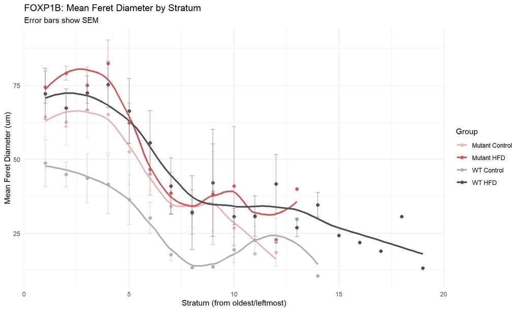

```r
ggplot(foxp1b_avg, aes(x = as.numeric(Stratum), y = Group_Mean_Feret, color = Simplified_Group)) +
  geom_smooth(method = "loess", se = FALSE, linewidth = 1.2, span = 0.6) +
  geom_point(size = 2) +
  geom_errorbar(aes(ymin = Group_Mean_Feret - Group_SEM_Feret,
                    ymax = Group_Mean_Feret + Group_SEM_Feret), width = 0.2, alpha = 0.5) +
  scale_color_manual(values = colors_foxp1b,
                     labels = c("mut_con" = "Mutant Control", "mut_hfd" = "Mutant HFD",
                                "wt_con" = "WT Control", "wt_hfd" = "WT HFD")) +
  theme_minimal() +
  labs(title = "FOXP1B: Mean Feret Diameter by Stratum",
       subtitle = "Error bars show SEM",
       x = "Stratum (from oldest/leftmost)", y = "Mean Feret Diameter (um)", color = "Group")
```

### Individual Fish with Group Means

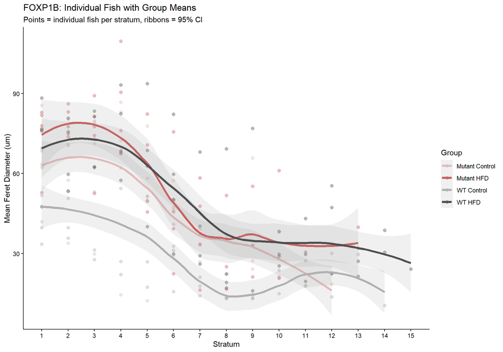

```r
ggplot() +
  geom_point(data = filter(foxp1b_data, as.numeric(Stratum) <= 15),
             aes(x = as.numeric(Stratum), y = Mean_Feret, color = Simplified_Group),
             alpha = 0.4, size = 2) +
  geom_smooth(data = filter(foxp1b_avg, as.numeric(Stratum) <= 15),
              aes(x = as.numeric(Stratum), y = Group_Mean_Feret, color = Simplified_Group),
              method = "loess", se = TRUE, linewidth = 1.5, span = 0.7, alpha = 0.15) +
  scale_color_manual(values = colors_foxp1b,
                     labels = c("mut_con" = "Mutant Control", "mut_hfd" = "Mutant HFD",
                                "wt_con" = "WT Control", "wt_hfd" = "WT HFD")) +
  scale_x_continuous(breaks = 1:15, limits = c(1, 15)) +
  theme_classic() +
  labs(title = "FOXP1B: Individual Fish with Group Means",
       subtitle = "Points = individual fish per stratum, ribbons = 95% CI",
       x = "Stratum", y = "Mean Feret Diameter (um)", color = "Group")
```

## Statistical Analysis

We fit a linear mixed effects model with Diet, Genotype, and Stratum as fixed effects (including all interactions), and Fish_Pair as a random effect to account for the paired design.

**Model formula:** `Mean_Feret ~ Diet x Genotype x Stratum_numeric + (1|Fish_Pair)`

```r
foxp1b_test <- foxp1b_data %>%
  filter(as.numeric(Stratum) <= 15) %>%
  mutate(Stratum_numeric = as.numeric(Stratum),
         Stratum_factor = as.factor(Stratum))

model_foxp1b <- lmer(Mean_Feret ~ Diet * Genotype * Stratum_numeric + (1|Fish_Pair),
                     data = foxp1b_test)

summary(model_foxp1b)
```

```
## Linear mixed model fit by REML. t-tests use Satterthwaite's method [
## lmerModLmerTest]
## Formula: Mean_Feret ~ Diet * Genotype * Stratum_numeric + (1 | Fish_Pair)
##    Data: foxp1b_test
##
## REML criterion at convergence: 1481.3
##
## Scaled residuals:
##      Min       1Q   Median       3Q      Max
## -2.65137 -0.56294 -0.01199  0.59631  2.78456
##
## Random effects:
##  Groups    Name        Variance Std.Dev.
##  Fish_Pair (Intercept)  57.17    7.561
##  Residual              215.31   14.673
## Number of obs: 182, groups:  Fish_Pair, 9
##
## Fixed effects:
##                                    Estimate Std. Error       df t value
## (Intercept)                         74.8646     5.5982  35.0694  13.373
## DietHFD                             13.0874     6.2558 168.4636   2.092
## GenotypeWT                         -23.2948     8.1345  31.3676  -2.864
## Stratum_numeric                     -4.7349     0.7518 170.7297  -6.298
## DietHFD:GenotypeWT                  15.7855     8.7860 168.0106   1.797
## DietHFD:Stratum_numeric             -0.9005     1.0461 170.9089  -0.861
## GenotypeWT:Stratum_numeric           1.0989     0.9987 170.6628   1.100
## DietHFD:GenotypeWT:Stratum_numeric   0.1550     1.3334 169.9264   0.116
##                                    Pr(>|t|)
## (Intercept)                        2.47e-15 ***
## DietHFD                              0.0379 *
## GenotypeWT                           0.0074 **
## Stratum_numeric                    2.47e-09 ***
## DietHFD:GenotypeWT                   0.0742 .
## DietHFD:Stratum_numeric              0.3906
## GenotypeWT:Stratum_numeric           0.2727
## DietHFD:GenotypeWT:Stratum_numeric   0.9076
## ---
## Signif. codes:  0 '***' 0.001 '**' 0.01 '*' 0.05 '.' 0.1 ' ' 1
##
## Correlation of Fixed Effects:
##             (Intr) DitHFD GntyWT Strtm_ DtHFD:GWT DHFD:S GWT:S_
## DietHFD     -0.569
## GenotypeWT  -0.688  0.392
## Stratm_nmrc -0.688  0.616  0.474
## DtHFD:GntWT  0.405 -0.712 -0.564 -0.439
## DtHFD:Strt_  0.496 -0.865 -0.341 -0.721  0.616
## GntypWT:St_  0.518 -0.464 -0.671 -0.753  0.616     0.543
## DHFD:GWT:S_ -0.389  0.678  0.500  0.566 -0.858    -0.785 -0.742
```

### Model Diagnostics

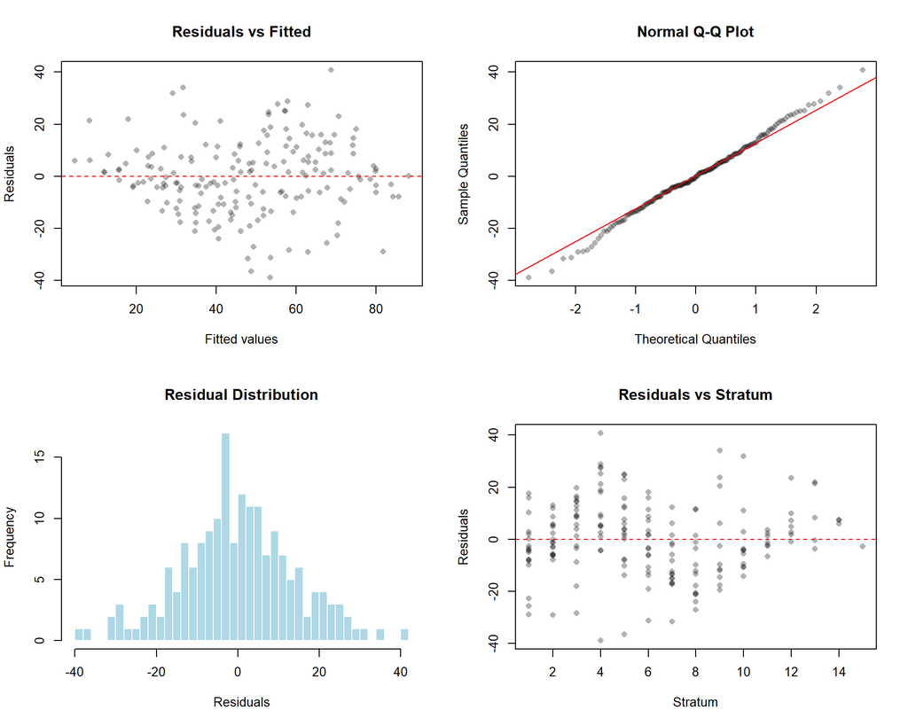

```r
par(mfrow = c(2, 2))

# Residuals vs Fitted
plot(fitted(model_foxp1b), resid(model_foxp1b),
     xlab = "Fitted values", ylab = "Residuals",
     main = "Residuals vs Fitted", pch = 16, col = adjustcolor("black", 0.3))
abline(h = 0, lty = 2, col = "red")

# QQ plot
qqnorm(resid(model_foxp1b), main = "Normal Q-Q Plot", pch = 16, col = adjustcolor("black", 0.3))
qqline(resid(model_foxp1b), col = "red")

# Histogram of residuals
hist(resid(model_foxp1b), breaks = 30, main = "Residual Distribution",
     xlab = "Residuals", col = "lightblue", border = "white")

# Residuals vs Stratum
plot(foxp1b_test$Stratum_numeric, resid(model_foxp1b),
     xlab = "Stratum", ylab = "Residuals",
     main = "Residuals vs Stratum", pch = 16, col = adjustcolor("black", 0.3))
abline(h = 0, lty = 2, col = "red")
```

```r
par(mfrow = c(1, 1))
```

**Diagnostic assessment:** Residuals appear approximately normally distributed with no strong systematic patterns across fitted values or strata, supporting model assumptions.

### ANOVA Table

```r
anova_foxp1b <- anova(model_foxp1b)
anova_foxp1b %>% as.data.frame() %>% kable(digits = 4, caption = "Type III ANOVA with Satterthwaite's method")
```

Type III ANOVA with Satterthwaite’s method

|  | Sum Sq | Mean Sq | NumDF | DenDF | F value | Pr(>F) |
| --- | --- | --- | --- | --- | --- | --- |
| Diet | 4910.8984 | 4910.8984 | 1 | 168.0106 | 22.8086 | 0.0000 |
| Genotype | 1131.6511 | 1131.6511 | 1 | 15.3520 | 5.2559 | 0.0364 |
| Stratum_numeric | 40071.6467 | 40071.6467 | 1 | 170.9845 | 186.1121 | 0.0000 |
| Diet:Genotype | 695.0210 | 695.0210 | 1 | 168.0106 | 3.2280 | 0.0742 |
| Diet:Stratum_numeric | 328.0635 | 328.0635 | 1 | 169.9264 | 1.5237 | 0.2188 |
| Genotype:Stratum_numeric | 656.1245 | 656.1245 | 1 | 170.9845 | 3.0474 | 0.0827 |
| Diet:Genotype:Stratum_numeric | 2.9099 | 2.9099 | 1 | 169.9264 | 0.0135 | 0.9076 |

**Key findings:**

- **Diet effect**: F = 22.81, p = 3.88e-06 (highly significant)
- **Genotype effect**: F = 5.26, p = 0.0364 (significant)
- **Diet x Genotype interaction**: F = 3.23, p = 0.0742
- **Diet x Genotype x Stratum**: F = 0.01, p = 0.908

### Post-hoc: Diet Effects Within Genotype

**Note on multiple testing:** We perform 15 contrasts per genotype (one per stratum). To control the false discovery rate, we apply Benjamini-Hochberg (FDR) correction within each family of contrasts. Both nominal and FDR-adjusted p-values are reported.

```r
emm_diet_b <- emmeans(model_foxp1b, pairwise ~ Diet | Genotype + Stratum_numeric,
                      at = list(Stratum_numeric = 1:15))
contrasts_b <- summary(emm_diet_b$contrasts)

# Split by genotype and apply FDR correction within each family
mut_diet_b <- contrasts_b[contrasts_b$Genotype == "Mutant", ]
mut_diet_b$p.adj <- p.adjust(mut_diet_b$p.value, method = "BH")

wt_diet_b <- contrasts_b[contrasts_b$Genotype == "WT", ]
wt_diet_b$p.adj <- p.adjust(wt_diet_b$p.value, method = "BH")
```

#### Mutant: Control vs HFD

```r
mut_diet_b %>%
  select(Stratum_numeric, estimate, SE, p.value, p.adj) %>%
  mutate(
    Nominal = ifelse(p.value < 0.05, "*", ""),
    FDR_Sig = ifelse(p.adj < 0.05, "*", "")
  ) %>%
  kable(digits = 3, caption = "Diet effect in mutants across strata (FDR-corrected)",
        col.names = c("Stratum", "Estimate", "SE", "p (nominal)", "p (FDR)", "Nom.", "FDR"))
```

Diet effect in mutants across strata (FDR-corrected)

|  | Stratum | Estimate | SE | p (nominal) | p (FDR) | Nom. | FDR |
| --- | --- | --- | --- | --- | --- | --- | --- |
| 1 | 1 | -12.187 | 5.381 | 0.025 | 0.062 | * |  |
| 3 | 2 | -11.287 | 4.571 | 0.015 | 0.055 | * |  |
| 5 | 3 | -10.386 | 3.879 | 0.008 | 0.041 | * | * |
| 7 | 4 | -9.486 | 3.376 | 0.006 | 0.041 | * | * |
| 9 | 5 | -8.585 | 3.155 | 0.007 | 0.041 | * | * |
| 11 | 6 | -7.685 | 3.273 | 0.020 | 0.060 | * |  |
| 13 | 7 | -6.784 | 3.699 | 0.068 | 0.146 |  |  |
| 15 | 8 | -5.884 | 4.342 | 0.177 | 0.332 |  |  |
| 17 | 9 | -4.983 | 5.122 | 0.332 | 0.553 |  |  |
| 19 | 10 | -4.083 | 5.985 | 0.496 | 0.744 |  |  |
| 21 | 11 | -3.182 | 6.899 | 0.645 | 0.880 |  |  |
| 23 | 12 | -2.282 | 7.848 | 0.772 | 0.964 |  |  |
| 25 | 13 | -1.381 | 8.820 | 0.876 | 0.969 |  |  |
| 27 | 14 | -0.481 | 9.808 | 0.961 | 0.969 |  |  |
| 29 | 15 | 0.420 | 10.808 | 0.969 | 0.969 |  |  |

**Summary**: HFD significantly increases droplet size in mutants at **3 strata** after FDR correction (3, 4, 5). Nominally significant (p < 0.05) at strata 1, 2, 3, 4, 5, 6. The effect is restricted to early/mature regions of the adipose tissue.

#### WT: Control vs HFD

```r
wt_diet_b %>%
  select(Stratum_numeric, estimate, SE, p.value, p.adj) %>%
  mutate(
    Nominal = ifelse(p.value < 0.05, "*", ""),
    FDR_Sig = ifelse(p.adj < 0.05, "*", "")
  ) %>%
  kable(digits = 4, caption = "Diet effect in WT across strata (FDR-corrected)",
        col.names = c("Stratum", "Estimate", "SE", "p (nominal)", "p (FDR)", "Nom.", "FDR"))
```

Diet effect in WT across strata (FDR-corrected)

|  | Stratum | Estimate | SE | p (nominal) | p (FDR) | Nom. | FDR |
| --- | --- | --- | --- | --- | --- | --- | --- |
| 2 | 1 | -28.1275 | 5.4729 | 0.0000 | 0.0000 | * | * |
| 4 | 2 | -27.3820 | 4.8168 | 0.0000 | 0.0000 | * | * |
| 6 | 3 | -26.6366 | 4.2214 | 0.0000 | 0.0000 | * | * |
| 8 | 4 | -25.8911 | 3.7159 | 0.0000 | 0.0000 | * | * |
| 10 | 5 | -25.1457 | 3.3415 | 0.0000 | 0.0000 | * | * |
| 12 | 6 | -24.4002 | 3.1453 | 0.0000 | 0.0000 | * | * |
| 14 | 7 | -23.6548 | 3.1606 | 0.0000 | 0.0000 | * | * |
| 16 | 8 | -22.9093 | 3.3845 | 0.0000 | 0.0000 | * | * |
| 18 | 9 | -22.1639 | 3.7803 | 0.0000 | 0.0000 | * | * |
| 20 | 10 | -21.4184 | 4.3006 | 0.0000 | 0.0000 | * | * |
| 22 | 11 | -20.6730 | 4.9060 | 0.0000 | 0.0001 | * | * |
| 24 | 12 | -19.9275 | 5.5689 | 0.0005 | 0.0006 | * | * |
| 26 | 13 | -19.1821 | 6.2710 | 0.0026 | 0.0030 | * | * |
| 28 | 14 | -18.4366 | 7.0006 | 0.0092 | 0.0099 | * | * |
| 30 | 15 | -17.6912 | 7.7498 | 0.0237 | 0.0237 | * | * |

**Summary**: HFD significantly increases droplet size in WT fish across **15 strata** after FDR correction (1, 2, 3, 4, 5, 6, 7, 8, 9, 10, 11, 12, 13, 14, 15). The sustained HFD response across strata contrasts with the restricted response in mutants.

### Post-hoc: Genotype Effects Within Diet

```r
emm_geno_b <- emmeans(model_foxp1b, pairwise ~ Genotype | Diet + Stratum_numeric,
                      at = list(Stratum_numeric = 1:15))
geno_contrasts_b <- summary(emm_geno_b$contrasts)

# Split by diet and apply FDR correction within each family
geno_con_b <- geno_contrasts_b[geno_contrasts_b$Diet == "Control", ] %>%
  mutate(Genotype_Effect = estimate)
geno_con_b$p.adj <- p.adjust(geno_con_b$p.value, method = "BH")

geno_hfd_b <- geno_contrasts_b[geno_contrasts_b$Diet == "HFD", ] %>%
  mutate(Genotype_Effect = estimate)
geno_hfd_b$p.adj <- p.adjust(geno_hfd_b$p.value, method = "BH")
```

#### Genotype Effect on Control Diet

```r
geno_con_b %>%
  select(Stratum_numeric, Genotype_Effect, SE, p.value, p.adj) %>%
  mutate(
    Nominal = ifelse(p.value < 0.05, "*", ""),
    FDR_Sig = ifelse(p.adj < 0.05, "*", "")
  ) %>%
  kable(digits = 3, caption = "Genotype effect (Mutant - WT) on control diet (FDR-corrected)",
        col.names = c("Stratum", "Effect", "SE", "p (nominal)", "p (FDR)", "Nom.", "FDR"))
```

Genotype effect (Mutant - WT) on control diet (FDR-corrected)

|  | Stratum | Effect | SE | p (nominal) | p (FDR) | Nom. | FDR |
| --- | --- | --- | --- | --- | --- | --- | --- |
| 1 | 1 | 22.196 | 7.503 | 0.007 | 0.043 | * | * |
| 3 | 2 | 21.097 | 6.955 | 0.008 | 0.043 | * | * |
| 5 | 3 | 19.998 | 6.516 | 0.009 | 0.043 | * | * |
| 7 | 4 | 18.899 | 6.209 | 0.011 | 0.043 | * | * |
| 9 | 5 | 17.800 | 6.054 | 0.015 | 0.046 | * | * |
| 11 | 6 | 16.701 | 6.063 | 0.021 | 0.052 | * |  |
| 13 | 7 | 15.602 | 6.235 | 0.030 | 0.064 | * |  |
| 15 | 8 | 14.503 | 6.557 | 0.045 | 0.085 | * |  |
| 17 | 9 | 13.404 | 7.010 | 0.073 | 0.122 |  |  |
| 19 | 10 | 12.305 | 7.568 | 0.118 | 0.177 |  |  |
| 21 | 11 | 11.206 | 8.212 | 0.183 | 0.249 |  |  |
| 23 | 12 | 10.108 | 8.922 | 0.264 | 0.330 |  |  |
| 25 | 13 | 9.009 | 9.683 | 0.357 | 0.411 |  |  |
| 27 | 14 | 7.910 | 10.486 | 0.453 | 0.486 |  |  |
| 29 | 15 | 6.811 | 11.320 | 0.549 | 0.549 |  |  |

**Summary**: Mutants have significantly larger droplets than WT on control diet at **5 strata** after FDR correction (1, 2, 3, 4, 5). Nominally significant at 8 strata. Mean effect in early strata (1-5): ~20 um.

#### Genotype Effect on HFD

```r
geno_hfd_b %>%
  select(Stratum_numeric, Genotype_Effect, SE, p.value, p.adj) %>%
  mutate(
    Nominal = ifelse(p.value < 0.05, "*", ""),
    FDR_Sig = ifelse(p.adj < 0.05, "*", "")
  ) %>%
  kable(digits = 3, caption = "Genotype effect (Mutant - WT) on HFD (FDR-corrected)",
        col.names = c("Stratum", "Effect", "SE", "p (nominal)", "p (FDR)", "Nom.", "FDR"))
```

Genotype effect (Mutant - WT) on HFD (FDR-corrected)

|  | Stratum | Effect | SE | p (nominal) | p (FDR) | Nom. | FDR |
| --- | --- | --- | --- | --- | --- | --- | --- |
| 2 | 1 | 6.255 | 7.361 | 0.405 | 0.864 |  |  |
| 4 | 2 | 5.001 | 6.871 | 0.477 | 0.864 |  |  |
| 6 | 3 | 3.747 | 6.469 | 0.573 | 0.864 |  |  |
| 8 | 4 | 2.494 | 6.172 | 0.694 | 0.868 |  |  |
| 10 | 5 | 1.240 | 5.996 | 0.841 | 0.901 |  |  |
| 12 | 6 | -0.014 | 5.951 | 0.998 | 0.998 |  |  |
| 14 | 7 | -1.268 | 6.041 | 0.838 | 0.901 |  |  |
| 16 | 8 | -2.522 | 6.259 | 0.695 | 0.868 |  |  |
| 18 | 9 | -3.776 | 6.594 | 0.576 | 0.864 |  |  |
| 20 | 10 | -5.030 | 7.027 | 0.484 | 0.864 |  |  |
| 22 | 11 | -6.284 | 7.543 | 0.414 | 0.864 |  |  |
| 24 | 12 | -7.538 | 8.125 | 0.361 | 0.864 |  |  |
| 26 | 13 | -8.792 | 8.761 | 0.322 | 0.864 |  |  |
| 28 | 14 | -10.046 | 9.439 | 0.293 | 0.864 |  |  |
| 30 | 15 | -11.300 | 10.151 | 0.270 | 0.864 |  |  |

**Summary**: On HFD, the genotype effect pattern shifts - no FDR-significant differences. This reflects WT mounting a sustained HFD response while mutants do not.

## Effect Plots

### Diet Effect

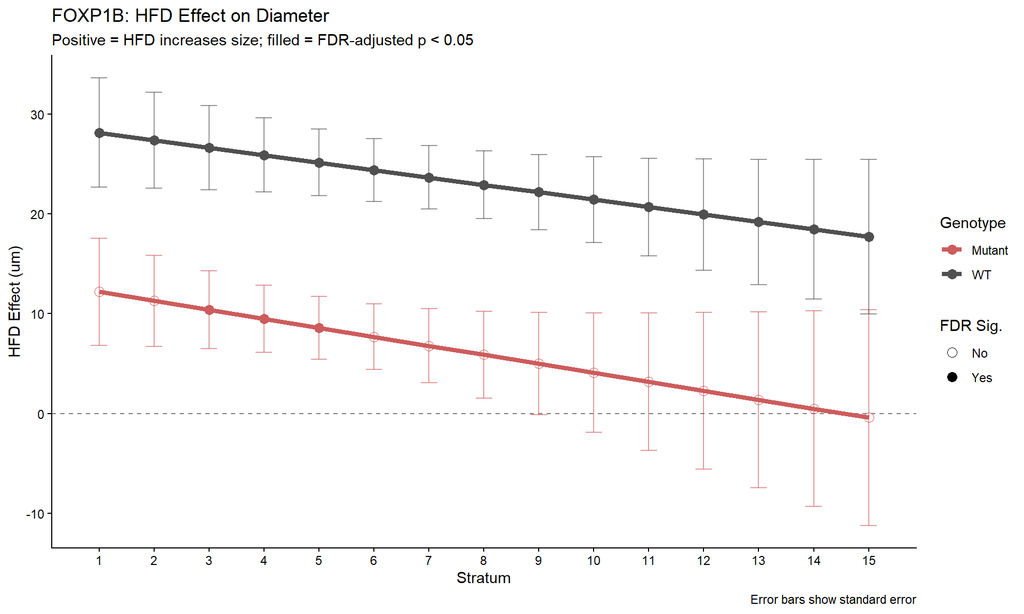

```r
diet_effects_b <- rbind(
  mut_diet_b %>% mutate(Genotype = "Mutant"),
  wt_diet_b %>% mutate(Genotype = "WT")
) %>% mutate(Diet_Effect = -estimate, FDR_Sig = ifelse(p.adj < 0.05, "Yes", "No"))

ggplot(diet_effects_b, aes(x = Stratum_numeric, y = Diet_Effect, color = Genotype)) +
  geom_hline(yintercept = 0, linetype = "dashed", color = "gray50") +
  geom_line(linewidth = 1.5) +
  geom_point(aes(shape = FDR_Sig), size = 3) +
  geom_errorbar(aes(ymin = Diet_Effect - SE, ymax = Diet_Effect + SE), width = 0.3, alpha = 0.6) +
  scale_color_manual(values = c("Mutant" = "#CD5C5C", "WT" = "#505050")) +
  scale_shape_manual(values = c("No" = 1, "Yes" = 16)) +
  scale_x_continuous(breaks = 1:15) +
  theme_classic() +
  labs(title = "FOXP1B: HFD Effect on Diameter",
       subtitle = "Positive = HFD increases size; filled = FDR-adjusted p < 0.05",
       x = "Stratum", y = "HFD Effect (um)", color = "Genotype", shape = "FDR Sig.",
       caption = "Error bars show standard error")
```

**Interpretation**: WT fish show a strong, persistent HFD response (~27 um in early strata, ~20 um in late strata). Mutants show a **weaker, transient response** (~10 um in early strata, declining to ~2 um by late strata). This represents an **~61% attenuation** of the HFD response in mutants.

### Combined Effects

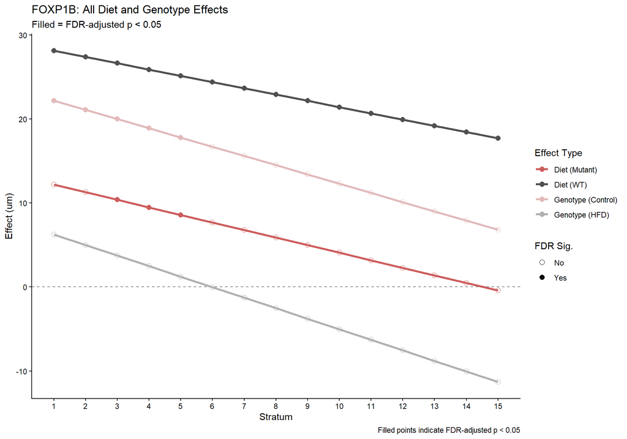

```r
diet_comb_b <- rbind(
  mut_diet_b %>% mutate(Effect_Type = "Diet (Mutant)"),
  wt_diet_b %>% mutate(Effect_Type = "Diet (WT)")
) %>% mutate(Effect_Size = -estimate, FDR_Sig = ifelse(p.adj < 0.05, "Yes", "No"))

geno_comb_b <- rbind(
  geno_con_b %>% mutate(Effect_Type = "Genotype (Control)"),
  geno_hfd_b %>% mutate(Effect_Type = "Genotype (HFD)")
) %>% select(Stratum_numeric, Effect_Type, Effect_Size = Genotype_Effect, SE, p.value, p.adj) %>%
  mutate(FDR_Sig = ifelse(p.adj < 0.05, "Yes", "No"))

all_effects_b <- rbind(
  diet_comb_b %>% select(Stratum_numeric, Effect_Type, Effect_Size, SE, p.value, p.adj, FDR_Sig),
  geno_comb_b
)

ggplot(all_effects_b, aes(x = Stratum_numeric, y = Effect_Size, color = Effect_Type)) +
  geom_hline(yintercept = 0, linetype = "dashed", color = "gray50") +
  geom_line(linewidth = 1.2) +
  geom_point(aes(shape = FDR_Sig), size = 2.5) +
  scale_shape_manual(values = c("No" = 1, "Yes" = 16)) +
  scale_color_manual(values = effect_colors_foxp1b) +
  scale_x_continuous(breaks = 1:15) +
  theme_classic() +
  labs(title = "FOXP1B: All Diet and Genotype Effects",
       subtitle = "Filled = FDR-adjusted p < 0.05",
       x = "Stratum", y = "Effect (um)", color = "Effect Type", shape = "FDR Sig.",
       caption = "Filled points indicate FDR-adjusted p < 0.05")
```

**Interpretation**: This combined plot shows all four key effects:

- **Diet (WT)** - Gray: Strong, persistent HFD effect throughout development
- **Genotype (Control)** - Light pink: Baseline mutant > WT effect (constitutive hypertrophy)
- **Diet (Mutant)** - Dark pink: Weak, transient HFD effect (early strata only)
- **Genotype (HFD)** - Light gray: Reversal effect - mutants start larger but WT overtakes in late strata

## Model Comparison

We compare three statistical models to validate our approach:

1. **Full Linear**: `Diet x Genotype x Stratum` (three-way interaction)
2. **Simple Linear**: `Diet x Genotype + Diet x Stratum + Genotype x Stratum` (no three-way)
3. **Categorical**: `Diet x Genotype x Stratum_factor` (stratum as factor)

```r
# Fit all three models
model_full_b <- lmer(Mean_Feret ~ Diet * Genotype * Stratum_numeric + (1|Fish_Pair),
                     data = foxp1b_test)

model_simple_b <- lmer(Mean_Feret ~ Diet * Genotype + Diet * Stratum_numeric +
                         Genotype * Stratum_numeric + (1|Fish_Pair),
                       data = foxp1b_test)

model_cat_b <- lmer(Mean_Feret ~ Diet * Genotype * Stratum_factor + (1|Fish_Pair),
                    data = foxp1b_test)
```

### ANOVA Comparison

```r
anova_full_b <- anova(model_full_b)
anova_simple_b <- anova(model_simple_b)
anova_cat_b <- anova(model_cat_b)

# Key interactions comparison
comparison_anova_b <- data.frame(
  Interaction = c("Diet x Genotype", "Diet x Stratum", "Genotype x Stratum"),
  Full_F = c(anova_full_b["Diet:Genotype", "F value"],
             anova_full_b["Diet:Stratum_numeric", "F value"],
             anova_full_b["Genotype:Stratum_numeric", "F value"]),
  Full_p = c(anova_full_b["Diet:Genotype", "Pr(>F)"],
             anova_full_b["Diet:Stratum_numeric", "Pr(>F)"],
             anova_full_b["Genotype:Stratum_numeric", "Pr(>F)"]),
  Simple_F = c(anova_simple_b["Diet:Genotype", "F value"],
               anova_simple_b["Diet:Stratum_numeric", "F value"],
               anova_simple_b["Genotype:Stratum_numeric", "F value"]),
  Simple_p = c(anova_simple_b["Diet:Genotype", "Pr(>F)"],
               anova_simple_b["Diet:Stratum_numeric", "Pr(>F)"],
               anova_simple_b["Genotype:Stratum_numeric", "Pr(>F)"])
)

comparison_anova_b %>% kable(digits = 4, caption = "ANOVA comparison across models")
```

ANOVA comparison across models

| Interaction | Full_F | Full_p | Simple_F | Simple_p |
| --- | --- | --- | --- | --- |
| Diet x Genotype | 3.2280 | 0.0742 | 13.7481 | 0.0003 |
| Diet x Stratum | 1.5237 | 0.2188 | 1.5490 | 0.2150 |
| Genotype x Stratum | 3.0474 | 0.0827 | 3.1469 | 0.0778 |

**Three-way interaction (Full Linear only):**  
F = 0.01, p = 0.908

### Model Fit Statistics

```r
model_fit_b <- data.frame(
  Model = c("Full Linear", "Simple Linear", "Categorical"),
  AIC = c(AIC(model_full_b), AIC(model_simple_b), AIC(model_cat_b)),
  BIC = c(BIC(model_full_b), BIC(model_simple_b), BIC(model_cat_b))
)

model_fit_b %>% kable(digits = 1, caption = "Model fit statistics (lower is better)")
```

Model fit statistics (lower is better)

| Model | AIC | BIC |
| --- | --- | --- |
| Full Linear | 1501.3 | 1533.4 |
| Simple Linear | 1501.8 | 1530.6 |
| Categorical | 1235.7 | 1415.1 |

### Significance Patterns

```r
# Extract effects from each model
emm_full_b <- emmeans(model_full_b, pairwise ~ Diet | Genotype + Stratum_numeric,
                      at = list(Stratum_numeric = 1:15))
emm_simple_b <- emmeans(model_simple_b, pairwise ~ Diet | Genotype + Stratum_numeric,
                        at = list(Stratum_numeric = 1:15))
emm_cat_b <- emmeans(model_cat_b, pairwise ~ Diet | Genotype + Stratum_factor)

con_full_b <- summary(emm_full_b$contrasts)
con_simple_b <- summary(emm_simple_b$contrasts)
con_cat_b <- summary(emm_cat_b$contrasts)

sig_patterns_b <- data.frame(
  Model = c("Full Linear", "Simple Linear", "Categorical"),
  WT_Diet_Sig = c(
    sum(con_full_b$p.value[con_full_b$Genotype == "WT"] < 0.05),
    sum(con_simple_b$p.value[con_simple_b$Genotype == "WT"] < 0.05),
    sum(con_cat_b$p.value[con_cat_b$Genotype == "WT"] < 0.05)
  ),
  Mutant_Diet_Sig = c(
    sum(con_full_b$p.value[con_full_b$Genotype == "Mutant"] < 0.05),
    sum(con_simple_b$p.value[con_simple_b$Genotype == "Mutant"] < 0.05),
    sum(con_cat_b$p.value[con_cat_b$Genotype == "Mutant"] < 0.05)
  )
)

sig_patterns_b %>% kable(caption = "Number of significant strata (out of 15) for diet effect")
```

Number of significant strata (out of 15) for diet effect

| Model | WT_Diet_Sig | Mutant_Diet_Sig |
| --- | --- | --- |
| Full Linear | 15 | 6 |
| Simple Linear | 15 | 7 |
| Categorical | NA | NA |

### Visual Comparison

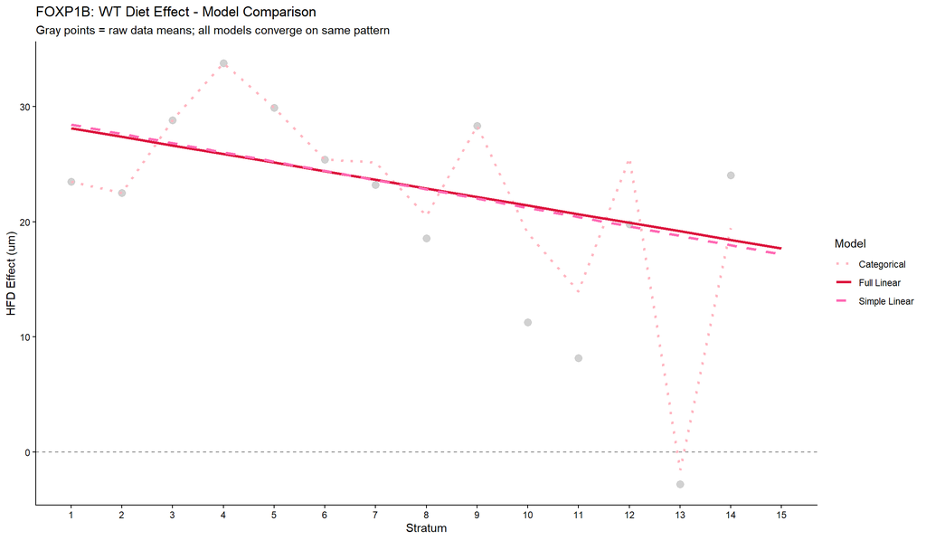

```r
# Extract WT diet effects from all models
wt_full_b <- con_full_b[con_full_b$Genotype == "WT", ] %>%
  mutate(Diet_Effect = -estimate, Model = "Full Linear")
wt_simple_b <- con_simple_b[con_simple_b$Genotype == "WT", ] %>%
  mutate(Diet_Effect = -estimate, Model = "Simple Linear")
wt_cat_b <- con_cat_b[con_cat_b$Genotype == "WT", ] %>%
  mutate(Stratum_numeric = as.numeric(as.character(Stratum_factor)),
         Diet_Effect = -estimate, Model = "Categorical")

# Combine
wt_all_models_b <- bind_rows(
  wt_full_b %>% select(Stratum_numeric, Diet_Effect, Model),
  wt_simple_b %>% select(Stratum_numeric, Diet_Effect, Model),
  wt_cat_b %>% select(Stratum_numeric, Diet_Effect, Model)
)

# Raw data for reference
raw_means_b <- foxp1b_test %>%
  group_by(Genotype, Diet, Stratum_numeric) %>%
  summarise(Mean_Diameter = mean(Mean_Feret, na.rm = TRUE), .groups = 'drop') %>%
  pivot_wider(names_from = Diet, values_from = Mean_Diameter) %>%
  mutate(Diet_Effect = HFD - Control) %>%
  filter(!is.na(Diet_Effect))

wt_raw_b <- raw_means_b %>% filter(Genotype == "WT")

ggplot() +
  geom_hline(yintercept = 0, linetype = "dashed", color = "gray50") +
  geom_point(data = wt_raw_b, aes(x = Stratum_numeric, y = Diet_Effect),
             size = 3, color = "gray70", alpha = 0.6) +
  geom_line(data = wt_all_models_b, aes(x = Stratum_numeric, y = Diet_Effect,
                                        color = Model, linetype = Model), linewidth = 1.2) +
  scale_color_manual(values = c("Full Linear" = "#DC143C",
                                "Simple Linear" = "#FF69B4",
                                "Categorical" = "#FFB6C1")) +
  scale_linetype_manual(values = c("Full Linear" = "solid",
                                   "Simple Linear" = "dashed",
                                   "Categorical" = "dotted")) +
  scale_x_continuous(breaks = 1:15) +
  theme_classic() +
  labs(title = "FOXP1B: WT Diet Effect - Model Comparison",
       subtitle = "Gray points = raw data means; all models converge on same pattern",
       x = "Stratum", y = "HFD Effect (um)")
```

### Model Comparison Summary

**Three-way interaction:** NOT significant (p = 0.908)

## Summary and Conclusions

### Biological Interpretation

This suggests foxp1b plays a critical role in the **adaptive metabolic response to dietary lipid excess**. The mutation may provide protection against diet-induced adipocyte hypertrophy while maintaining elevated baseline adipocyte size through an alternative mechanism.

# Foxp1a (ed116) Analysis

```r
foxp1a_data <- all_data %>% filter(Experiment == "foxp1a")
foxp1a_avg <- group_averages %>% filter(Experiment == "foxp1a")
```

## Sample Sizes

```r
foxp1a_data %>%
  group_by(Genotype, Diet) %>%
  summarise(N_Fish = n_distinct(Fish_Pair), N_Observations = n(), .groups = 'drop') %>%
  kable(caption = "Foxp1a sample sizes by genotype and diet")
```

Foxp1a sample sizes by genotype and diet

| Genotype | Diet | N_Fish | N_Observations |
| --- | --- | --- | --- |
| Mutant | Control | 5 | 66 |
| Mutant | HFD | 4 | 58 |
| WT | Control | 5 | 58 |
| WT | HFD | 5 | 63 |

### Verify Pairing Structure

```r
foxp1a_data %>%
  select(Fish_ID, Genotype, Diet, Fish_Pair) %>%
  distinct() %>%
  arrange(Fish_Pair, Diet) %>%
  kable(caption = "Paired structure showing same fish under both diet conditions")
```

Paired structure showing same fish under both diet conditions

| Fish_ID | Genotype | Diet | Fish_Pair |
| --- | --- | --- | --- |
| ed116_con_1_CO_cp_masks_merged | Mutant | Control | Mutant_1 |
| ed116_hfd_1_CO_cp_masks_merged | Mutant | HFD | Mutant_1 |
| ed116_con_2_CO_cp_masks_merged | Mutant | Control | Mutant_2 |
| ed116_hfd_2_CO_cp_masks_merged | Mutant | HFD | Mutant_2 |
| ed116_con_3_CO_cp_masks_merged | Mutant | Control | Mutant_3 |
| ed116_hfd_3_CO_cp_masks_merged | Mutant | HFD | Mutant_3 |
| ed116_con_4_CO_cp_masks_merged | Mutant | Control | Mutant_4 |
| ed116_hfd_4_CO_cp_masks_merged | Mutant | HFD | Mutant_4 |
| ed116_con_5_CO_cp_masks_merged | Mutant | Control | Mutant_5 |
| wted116_con_1_CO_merged | WT | Control | WT_1 |
| wted116_hfd_1_CO_cp_masks_merged | WT | HFD | WT_1 |
| wted116_con_2_CO_merged | WT | Control | WT_2 |
| wted116_hfd_2_CO_cp_masks_merged | WT | HFD | WT_2 |
| wted116_con_3_CO_merged | WT | Control | WT_3 |
| wted116_hfd_3_CO_cp_masks_merged | WT | HFD | WT_3 |
| wted116_con_4_CO_merged | WT | Control | WT_4 |
| wted116_hfd_4_CO_cp_masks_merged | WT | HFD | WT_4 |
| wted116_con_5_CO_merged | WT | Control | WT_5 |
| wted116_hfd_5_CO_cp_masks_merged | WT | HFD | WT_5 |

## Trajectory Plots

### Group Means with SEM

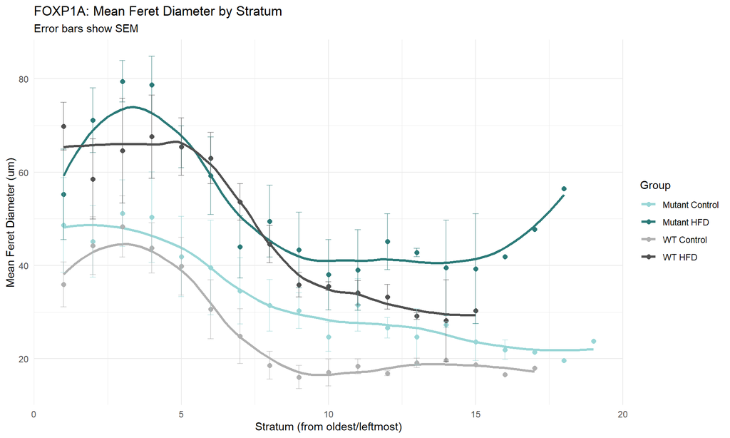

```r
ggplot(foxp1a_avg, aes(x = as.numeric(Stratum), y = Group_Mean_Feret, color = Simplified_Group)) +
  geom_smooth(method = "loess", se = FALSE, linewidth = 1.2, span = 0.6) +
  geom_point(size = 2) +
  geom_errorbar(aes(ymin = Group_Mean_Feret - Group_SEM_Feret,
                    ymax = Group_Mean_Feret + Group_SEM_Feret), width = 0.2, alpha = 0.5) +
  scale_color_manual(values = colors_foxp1a,
                     labels = c("mut_con" = "Mutant Control", "mut_hfd" = "Mutant HFD",
                                "wt_con" = "WT Control", "wt_hfd" = "WT HFD")) +
  theme_minimal() +
  labs(title = "FOXP1A: Mean Feret Diameter by Stratum",
       subtitle = "Error bars show SEM",
       x = "Stratum (from oldest/leftmost)", y = "Mean Feret Diameter (um)", color = "Group")
```

### Individual Fish with Group Means

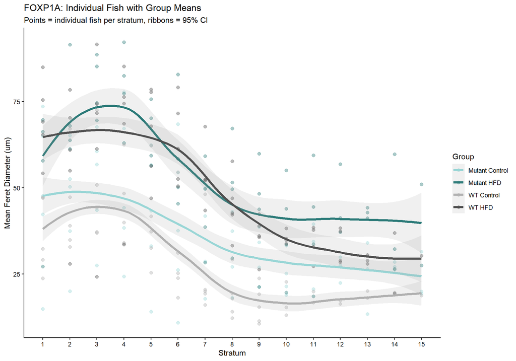

```r
ggplot() +
  geom_point(data = filter(foxp1a_data, as.numeric(Stratum) <= 15),
             aes(x = as.numeric(Stratum), y = Mean_Feret, color = Simplified_Group),
             alpha = 0.4, size = 2) +
  geom_smooth(data = filter(foxp1a_avg, as.numeric(Stratum) <= 15),
              aes(x = as.numeric(Stratum), y = Group_Mean_Feret, color = Simplified_Group),
              method = "loess", se = TRUE, linewidth = 1.5, span = 0.7, alpha = 0.15) +
  scale_color_manual(values = colors_foxp1a,
                     labels = c("mut_con" = "Mutant Control", "mut_hfd" = "Mutant HFD",
                                "wt_con" = "WT Control", "wt_hfd" = "WT HFD")) +
  scale_x_continuous(breaks = 1:15, limits = c(1, 15)) +
  theme_classic() +
  labs(title = "FOXP1A: Individual Fish with Group Means",
       subtitle = "Points = individual fish per stratum, ribbons = 95% CI",
       x = "Stratum", y = "Mean Feret Diameter (um)", color = "Group")
```

## Statistical Analysis

We fit a linear mixed effects model with Diet, Genotype, and Stratum as fixed effects (including all interactions), and Fish_Pair as a random effect to account for the paired design.

**Model formula:** `Mean_Feret ~ Diet x Genotype x Stratum_numeric + (1|Fish_Pair)`

```r
foxp1a_test <- foxp1a_data %>%
  filter(as.numeric(Stratum) <= 15) %>%
  mutate(Stratum_numeric = as.numeric(Stratum),
         Stratum_factor = as.factor(Stratum))

model_foxp1a <- lmer(Mean_Feret ~ Diet * Genotype * Stratum_numeric + (1|Fish_Pair),
                     data = foxp1a_test)

summary(model_foxp1a)
```

```
## Linear mixed model fit by REML. t-tests use Satterthwaite's method [
## lmerModLmerTest]
## Formula: Mean_Feret ~ Diet * Genotype * Stratum_numeric + (1 | Fish_Pair)
##    Data: foxp1a_test
##
## REML criterion at convergence: 1827.8
##
## Scaled residuals:
##      Min       1Q   Median       3Q      Max
## -3.06352 -0.50038 -0.02768  0.56857  2.67339
##
## Random effects:
##  Groups    Name        Variance Std.Dev.
##  Fish_Pair (Intercept)  61.17    7.821
##  Residual              139.60   11.815
## Number of obs: 235, groups:  Fish_Pair, 10
##
## Fixed effects:
##                                    Estimate Std. Error       df t value
## (Intercept)                         53.5771     4.6047  19.4781  11.635
## DietHFD                             20.8614     4.4965 220.1136   4.639
## GenotypeWT                          -4.1104     6.6043  20.5545  -0.622
## Stratum_numeric                     -2.5178     0.3696 221.8562  -6.813
## DietHFD:GenotypeWT                   6.5941     6.2983 219.6897   1.047
## DietHFD:Stratum_numeric             -0.2766     0.5404 221.1835  -0.512
## GenotypeWT:Stratum_numeric          -0.6097     0.5766 221.4062  -1.057
## DietHFD:GenotypeWT:Stratum_numeric  -0.4918     0.7941 220.4256  -0.619
##                                    Pr(>|t|)
## (Intercept)                        3.23e-10 ***
## DietHFD                            5.99e-06 ***
## GenotypeWT                            0.541
## Stratum_numeric                    8.90e-11 ***
## DietHFD:GenotypeWT                    0.296
## DietHFD:Stratum_numeric               0.609
## GenotypeWT:Stratum_numeric            0.291
## DietHFD:GenotypeWT:Stratum_numeric    0.536
## ---
## Signif. codes:  0 '***' 0.001 '**' 0.01 '*' 0.05 '.' 0.1 ' ' 1
##
## Correlation of Fixed Effects:
##             (Intr) DitHFD GntyWT Strtm_ DtHFD:GWT DHFD:S GWT:S_
## DietHFD     -0.430
## GenotypeWT  -0.697  0.300
## Stratm_nmrc -0.556  0.555  0.388
## DtHFD:GntWT  0.307 -0.714 -0.457 -0.396
## DtHFD:Strt_  0.383 -0.847 -0.267 -0.692  0.605
## GntypWT:St_  0.357 -0.355 -0.570 -0.641  0.585     0.443
## DHFD:GWT:S_ -0.261  0.577  0.412  0.471 -0.857    -0.681 -0.720
```

### Model Diagnostics

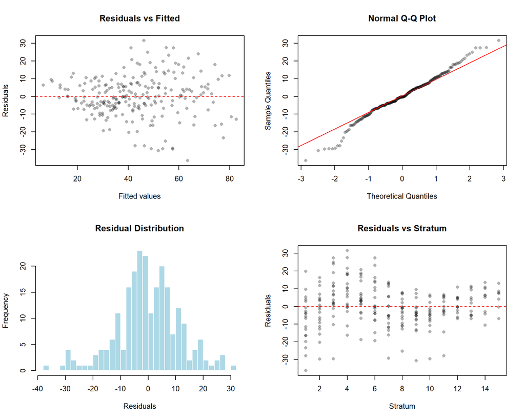

```r
par(mfrow = c(2, 2))

# Residuals vs Fitted
plot(fitted(model_foxp1a), resid(model_foxp1a),
     xlab = "Fitted values", ylab = "Residuals",
     main = "Residuals vs Fitted", pch = 16, col = adjustcolor("black", 0.3))
abline(h = 0, lty = 2, col = "red")

# QQ plot
qqnorm(resid(model_foxp1a), main = "Normal Q-Q Plot", pch = 16, col = adjustcolor("black", 0.3))
qqline(resid(model_foxp1a), col = "red")

# Histogram of residuals
hist(resid(model_foxp1a), breaks = 30, main = "Residual Distribution",
     xlab = "Residuals", col = "lightblue", border = "white")

# Residuals vs Stratum
plot(foxp1a_test$Stratum_numeric, resid(model_foxp1a),
     xlab = "Stratum", ylab = "Residuals",
     main = "Residuals vs Stratum", pch = 16, col = adjustcolor("black", 0.3))
abline(h = 0, lty = 2, col = "red")
```

```r
par(mfrow = c(1, 1))
```

**Diagnostic assessment:** Residuals appear approximately normally distributed with no strong systematic patterns across fitted values or strata, supporting model assumptions.

### ANOVA Table

```r
anova_foxp1a <- anova(model_foxp1a)
anova_foxp1a %>% as.data.frame() %>% kable(digits = 4, caption = "Type III ANOVA with Satterthwaite's method")
```

Type III ANOVA with Satterthwaite’s method

|  | Sum Sq | Mean Sq | NumDF | DenDF | F value | Pr(>F) |
| --- | --- | --- | --- | --- | --- | --- |
| Diet | 8215.4615 | 8215.4615 | 1 | 219.6897 | 58.8499 | 0.0000 |
| Genotype | 2.6739 | 2.6739 | 1 | 13.0187 | 0.0192 | 0.8920 |
| Stratum_numeric | 33113.0149 | 33113.0149 | 1 | 221.0415 | 237.1988 | 0.0000 |
| Diet:Genotype | 153.0209 | 153.0209 | 1 | 219.6897 | 1.0961 | 0.2963 |
| Diet:Stratum_numeric | 241.6984 | 241.6984 | 1 | 220.4256 | 1.7314 | 0.1896 |
| Genotype:Stratum_numeric | 637.2399 | 637.2399 | 1 | 221.0415 | 4.5647 | 0.0337 |
| Diet:Genotype:Stratum_numeric | 53.5392 | 53.5392 | 1 | 220.4256 | 0.3835 | 0.5364 |

**Key findings:**

- **Diet effect**: F = 58.85, p = 5.48e-13
- **Genotype effect**: F = 0.02, p = 0.892
- **Diet x Genotype interaction**: F = 1.1, p = 0.296
- **Diet x Genotype x Stratum**: F = 0.38, p = 0.536

### Post-hoc: Diet Effects Within Genotype

**Note on multiple testing:** We perform 15 contrasts per genotype (one per stratum). To control the false discovery rate, we apply Benjamini-Hochberg (FDR) correction within each family of contrasts.

```r
emm_diet_a <- emmeans(model_foxp1a, pairwise ~ Diet | Genotype + Stratum_numeric,
                      at = list(Stratum_numeric = 1:15))
contrasts_a <- summary(emm_diet_a$contrasts)

# Split by genotype and apply FDR correction within each family
mut_diet_a <- contrasts_a[contrasts_a$Genotype == "Mutant", ]
mut_diet_a$p.adj <- p.adjust(mut_diet_a$p.value, method = "BH")

wt_diet_a <- contrasts_a[contrasts_a$Genotype == "WT", ]
wt_diet_a$p.adj <- p.adjust(wt_diet_a$p.value, method = "BH")
```

#### Mutant: Control vs HFD

```r
mut_diet_a %>%
  select(Stratum_numeric, estimate, SE, p.value, p.adj) %>%
  mutate(
    Nominal = ifelse(p.value < 0.05, "*", ""),
    FDR_Sig = ifelse(p.adj < 0.05, "*", "")
  ) %>%
  kable(digits = 3, caption = "Diet effect in mutants across strata (FDR-corrected)",
        col.names = c("Stratum", "Estimate", "SE", "p (nominal)", "p (FDR)", "Nom.", "FDR"))
```

Diet effect in mutants across strata (FDR-corrected)

|  | Stratum | Estimate | SE | p (nominal) | p (FDR) | Nom. | FDR |
| --- | --- | --- | --- | --- | --- | --- | --- |
| 1 | 1 | -20.585 | 4.052 | 0.000 | 0.000 | * | * |
| 3 | 2 | -20.308 | 3.631 | 0.000 | 0.000 | * | * |
| 5 | 3 | -20.032 | 3.245 | 0.000 | 0.000 | * | * |
| 7 | 4 | -19.755 | 2.909 | 0.000 | 0.000 | * | * |
| 9 | 5 | -19.479 | 2.642 | 0.000 | 0.000 | * | * |
| 11 | 6 | -19.202 | 2.466 | 0.000 | 0.000 | * | * |
| 13 | 7 | -18.925 | 2.403 | 0.000 | 0.000 | * | * |
| 15 | 8 | -18.649 | 2.459 | 0.000 | 0.000 | * | * |
| 17 | 9 | -18.372 | 2.629 | 0.000 | 0.000 | * | * |
| 19 | 10 | -18.096 | 2.891 | 0.000 | 0.000 | * | * |
| 21 | 11 | -17.819 | 3.223 | 0.000 | 0.000 | * | * |
| 23 | 12 | -17.543 | 3.607 | 0.000 | 0.000 | * | * |
| 25 | 13 | -17.266 | 4.026 | 0.000 | 0.000 | * | * |
| 27 | 14 | -16.989 | 4.472 | 0.000 | 0.000 | * | * |
| 29 | 15 | -16.713 | 4.937 | 0.001 | 0.001 | * | * |

**Summary**: HFD significantly affects droplet size in foxp1a mutants at 15 strata after FDR correction ( 1, 2, 3, 4, 5, 6, 7, 8, 9, 10, 11, 12, 13, 14, 15 ). Nominally significant at 15 strata. Unlike WT (and foxp1b mutants), foxp1a mutants show a **flattened, uniform response** across all strata.

#### WT: Control vs HFD

```r
wt_diet_a %>%
  select(Stratum_numeric, estimate, SE, p.value, p.adj) %>%
  mutate(
    Nominal = ifelse(p.value < 0.05, "*", ""),
    FDR_Sig = ifelse(p.adj < 0.05, "*", "")
  ) %>%
  kable(digits = 4, caption = "Diet effect in WT across strata (FDR-corrected)",
        col.names = c("Stratum", "Estimate", "SE", "p (nominal)", "p (FDR)", "Nom.", "FDR"))
```

Diet effect in WT across strata (FDR-corrected)

|  | Stratum | Estimate | SE | p (nominal) | p (FDR) | Nom. | FDR |
| --- | --- | --- | --- | --- | --- | --- | --- |
| 2 | 1 | -26.6872 | 3.9159 | 0.0000 | 0.0000 | * | * |
| 4 | 2 | -25.9188 | 3.4484 | 0.0000 | 0.0000 | * | * |
| 6 | 3 | -25.1504 | 3.0210 | 0.0000 | 0.0000 | * | * |
| 8 | 4 | -24.3821 | 2.6532 | 0.0000 | 0.0000 | * | * |
| 10 | 5 | -23.6137 | 2.3727 | 0.0000 | 0.0000 | * | * |
| 12 | 6 | -22.8453 | 2.2131 | 0.0000 | 0.0000 | * | * |
| 14 | 7 | -22.0770 | 2.2008 | 0.0000 | 0.0000 | * | * |
| 16 | 8 | -21.3086 | 2.3382 | 0.0000 | 0.0000 | * | * |
| 18 | 9 | -20.5402 | 2.6016 | 0.0000 | 0.0000 | * | * |
| 20 | 10 | -19.7719 | 2.9576 | 0.0000 | 0.0000 | * | * |
| 22 | 11 | -19.0035 | 3.3770 | 0.0000 | 0.0000 | * | * |
| 24 | 12 | -18.2351 | 3.8391 | 0.0000 | 0.0000 | * | * |
| 26 | 13 | -17.4668 | 4.3303 | 0.0001 | 0.0001 | * | * |
| 28 | 14 | -16.6984 | 4.8416 | 0.0007 | 0.0007 | * | * |
| 30 | 15 | -15.9301 | 5.3674 | 0.0033 | 0.0033 | * | * |

**Summary**: HFD significantly affects droplet size in WT fish at 15 strata after FDR correction ( 1, 2, 3, 4, 5, 6, 7, 8, 9, 10, 11, 12, 13, 14, 15 ) - showing the expected spatial gradient with stronger effects in mature (early) strata. WT fish maintain normal **spatial patterning** of the HFD response.

### Post-hoc: Genotype Effects Within Diet

```r
emm_geno_a <- emmeans(model_foxp1a, pairwise ~ Genotype | Diet + Stratum_numeric,
                      at = list(Stratum_numeric = 1:15))
geno_contrasts_a <- summary(emm_geno_a$contrasts)

# Split by diet and apply FDR correction within each family
geno_con_a <- geno_contrasts_a[geno_contrasts_a$Diet == "Control", ] %>%
  mutate(Genotype_Effect = estimate)
geno_con_a$p.adj <- p.adjust(geno_con_a$p.value, method = "BH")

geno_hfd_a <- geno_contrasts_a[geno_contrasts_a$Diet == "HFD", ] %>%
  mutate(Genotype_Effect = estimate)
geno_hfd_a$p.adj <- p.adjust(geno_hfd_a$p.value, method = "BH")
```

#### Genotype Effect on Control Diet

```r
geno_con_a %>%
  select(Stratum_numeric, Genotype_Effect, SE, p.value, p.adj) %>%
  mutate(
    Nominal = ifelse(p.value < 0.05, "*", ""),
    FDR_Sig = ifelse(p.adj < 0.05, "*", "")
  ) %>%
  kable(digits = 3, caption = "Genotype effect (Mutant - WT) on control diet (FDR-corrected)",
        col.names = c("Stratum", "Effect", "SE", "p (nominal)", "p (FDR)", "Nom.", "FDR"))
```

Genotype effect (Mutant - WT) on control diet (FDR-corrected)

|  | Stratum | Effect | SE | p (nominal) | p (FDR) | Nom. | FDR |
| --- | --- | --- | --- | --- | --- | --- | --- |
| 1 | 1 | 4.720 | 6.294 | 0.464 | 0.464 |  |  |
| 3 | 2 | 5.330 | 6.022 | 0.391 | 0.419 |  |  |
| 5 | 3 | 5.940 | 5.796 | 0.325 | 0.375 |  |  |
| 7 | 4 | 6.549 | 5.619 | 0.269 | 0.336 |  |  |
| 9 | 5 | 7.159 | 5.498 | 0.222 | 0.303 |  |  |
| 11 | 6 | 7.769 | 5.436 | 0.185 | 0.277 |  |  |
| 13 | 7 | 8.378 | 5.435 | 0.156 | 0.260 |  |  |
| 15 | 8 | 8.988 | 5.495 | 0.133 | 0.250 |  |  |
| 17 | 9 | 9.598 | 5.614 | 0.116 | 0.248 |  |  |
| 19 | 10 | 10.208 | 5.789 | 0.103 | 0.248 |  |  |
| 21 | 11 | 10.817 | 6.014 | 0.094 | 0.248 |  |  |
| 23 | 12 | 11.427 | 6.284 | 0.087 | 0.248 |  |  |
| 25 | 13 | 12.037 | 6.594 | 0.083 | 0.248 |  |  |
| 27 | 14 | 12.647 | 6.938 | 0.081 | 0.248 |  |  |
| 29 | 15 | 13.256 | 7.312 | 0.080 | 0.248 |  |  |

**Summary**: No FDR-significant genotype effect on control diet (nominally significant at 0 strata), though there is a trend toward larger adipocytes in mutants (~ 6 um in early strata).

#### Genotype Effect on HFD

```r
geno_hfd_a %>%
  select(Stratum_numeric, Genotype_Effect, SE, p.value, p.adj) %>%
  mutate(
    Nominal = ifelse(p.value < 0.05, "*", ""),
    FDR_Sig = ifelse(p.adj < 0.05, "*", "")
  ) %>%
  kable(digits = 3, caption = "Genotype effect (Mutant - WT) on HFD (FDR-corrected)",
        col.names = c("Stratum", "Effect", "SE", "p (nominal)", "p (FDR)", "Nom.", "FDR"))
```

Genotype effect (Mutant - WT) on HFD (FDR-corrected)

|  | Stratum | Effect | SE | p (nominal) | p (FDR) | Nom. | FDR |
| --- | --- | --- | --- | --- | --- | --- | --- |
| 2 | 1 | -1.382 | 6.426 | 0.832 | 0.955 |  |  |
| 4 | 2 | -0.281 | 6.152 | 0.964 | 0.964 |  |  |
| 6 | 3 | 0.821 | 5.918 | 0.892 | 0.955 |  |  |
| 8 | 4 | 1.922 | 5.727 | 0.743 | 0.929 |  |  |
| 10 | 5 | 3.024 | 5.585 | 0.599 | 0.817 |  |  |
| 12 | 6 | 4.125 | 5.494 | 0.470 | 0.705 |  |  |
| 14 | 7 | 5.227 | 5.457 | 0.362 | 0.603 |  |  |
| 16 | 8 | 6.328 | 5.477 | 0.275 | 0.516 |  |  |
| 18 | 9 | 7.430 | 5.551 | 0.210 | 0.449 |  |  |
| 20 | 10 | 8.531 | 5.678 | 0.161 | 0.401 |  |  |
| 22 | 11 | 9.633 | 5.854 | 0.124 | 0.373 |  |  |
| 24 | 12 | 10.735 | 6.076 | 0.098 | 0.368 |  |  |
| 26 | 13 | 11.836 | 6.337 | 0.079 | 0.368 |  |  |
| 28 | 14 | 12.938 | 6.635 | 0.065 | 0.368 |  |  |
| 30 | 15 | 14.039 | 6.963 | 0.055 | 0.368 |  |  |

## Effect Plots

### Diet Effect

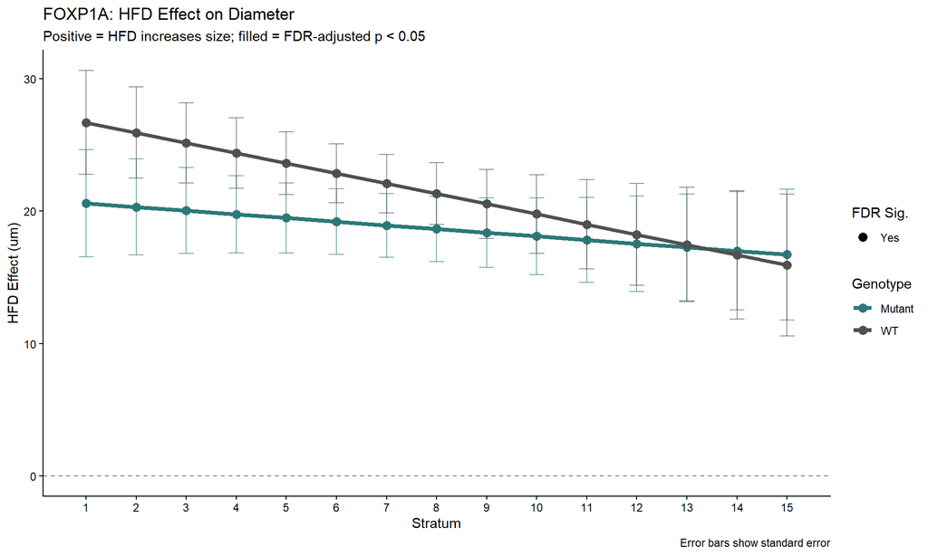

```r
diet_effects_a <- rbind(
  mut_diet_a %>% mutate(Genotype = "Mutant"),
  wt_diet_a %>% mutate(Genotype = "WT")
) %>% mutate(Diet_Effect = -estimate, FDR_Sig = ifelse(p.adj < 0.05, "Yes", "No"))

ggplot(diet_effects_a, aes(x = Stratum_numeric, y = Diet_Effect, color = Genotype)) +
  geom_hline(yintercept = 0, linetype = "dashed", color = "gray50") +
  geom_line(linewidth = 1.5) +
  geom_point(aes(shape = FDR_Sig), size = 3) +
  geom_errorbar(aes(ymin = Diet_Effect - SE, ymax = Diet_Effect + SE), width = 0.3, alpha = 0.6) +
  scale_color_manual(values = c("Mutant" = "#2B7A78", "WT" = "#505050")) +
  scale_shape_manual(values = c("No" = 1, "Yes" = 16)) +
  scale_x_continuous(breaks = 1:15) +
  theme_classic() +
  labs(title = "FOXP1A: HFD Effect on Diameter",
       subtitle = "Positive = HFD increases size; filled = FDR-adjusted p < 0.05",
       x = "Stratum", y = "HFD Effect (um)", color = "Genotype", shape = "FDR Sig.",
       caption = "Error bars show standard error")
```

**Interpretation**:

- **WT**: Shows the expected **spatial gradient** - stronger HFD response in early/mature strata (~25 um) declining toward late/young strata (~18 um).
- **Mutant**: Shows a **flattened, uniform response** across all strata (~20 um early, ~17 um late) - the normal spatial gradient is **abolished**.
- **Attenuation**: In early strata, the mutant HFD response is **~20% reduced** compared to WT (20 um vs 25 um).

### Genotype Effect on Control Diet

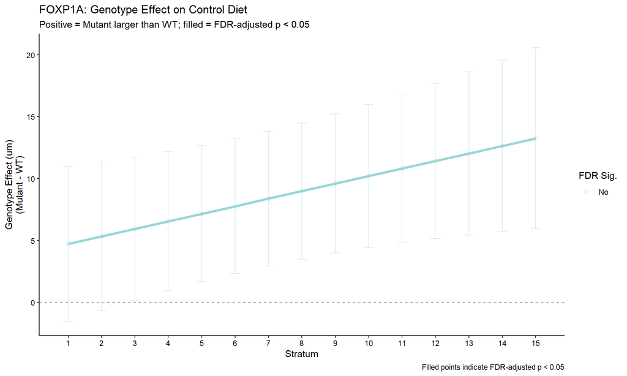

```r
geno_con_a <- geno_con_a %>% mutate(FDR_Sig = ifelse(p.adj < 0.05, "Yes", "No"))

ggplot(geno_con_a, aes(x = Stratum_numeric, y = Genotype_Effect)) +
  geom_hline(yintercept = 0, linetype = "dashed", color = "gray50") +
  geom_line(linewidth = 1.5, color = "#99D6D6") +
  geom_point(aes(shape = FDR_Sig, size = FDR_Sig), color = "#99D6D6") +
  geom_errorbar(aes(ymin = Genotype_Effect - SE, ymax = Genotype_Effect + SE),
                width = 0.3, alpha = 0.4, color = "#99D6D6") +
  scale_shape_manual(values = c("No" = 1, "Yes" = 16)) +
  scale_size_manual(values = c("No" = 2, "Yes" = 3)) +
  scale_x_continuous(breaks = 1:15) +
  theme_classic() +
  labs(title = "FOXP1A: Genotype Effect on Control Diet",
       subtitle = "Positive = Mutant larger than WT; filled = FDR-adjusted p < 0.05",
       x = "Stratum", y = "Genotype Effect (um)\n(Mutant - WT)",
       shape = "FDR Sig.", size = "FDR Sig.",
       caption = "Filled points indicate FDR-adjusted p < 0.05")
```

### Combined Effects

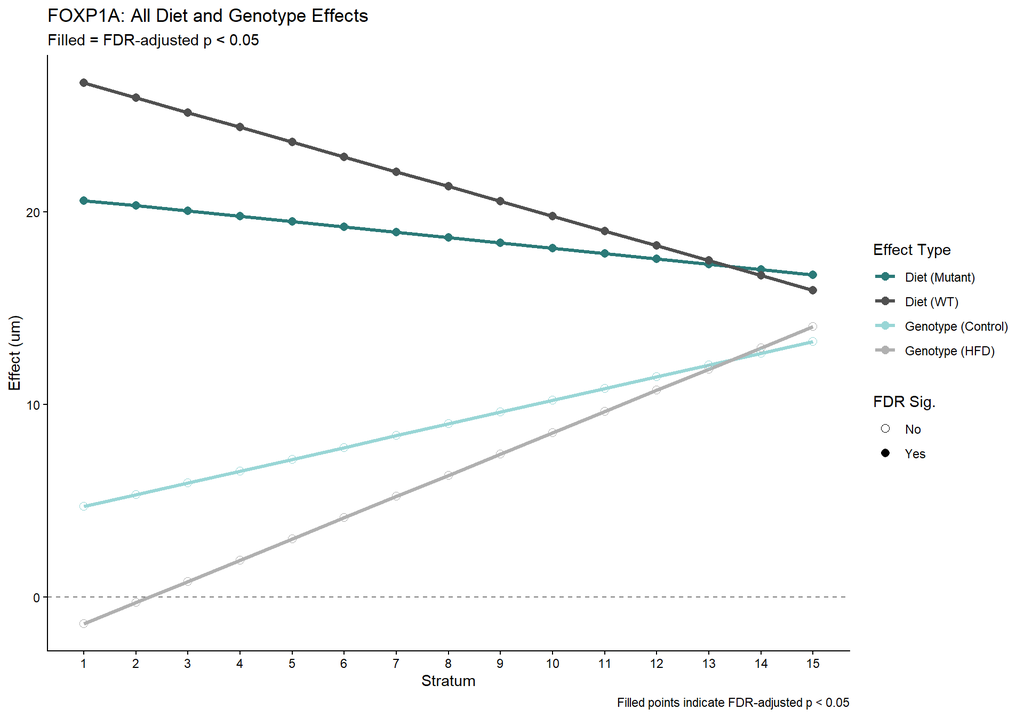

```r
diet_comb_a <- rbind(
  mut_diet_a %>% mutate(Effect_Type = "Diet (Mutant)"),
  wt_diet_a %>% mutate(Effect_Type = "Diet (WT)")
) %>% mutate(Effect_Size = -estimate, FDR_Sig = ifelse(p.adj < 0.05, "Yes", "No"))

# Add FDR_Sig to geno_hfd_a to match geno_con_a structure
geno_hfd_a <- geno_hfd_a %>% mutate(FDR_Sig = ifelse(p.adj < 0.05, "Yes", "No"))

geno_comb_a <- rbind(
  geno_con_a %>% mutate(Effect_Type = "Genotype (Control)"),
  geno_hfd_a %>% mutate(Effect_Type = "Genotype (HFD)")
) %>% select(Stratum_numeric, Effect_Type, Effect_Size = Genotype_Effect, SE, p.value, p.adj, FDR_Sig)

all_effects_a <- rbind(
  diet_comb_a %>% select(Stratum_numeric, Effect_Type, Effect_Size, SE, p.value, p.adj, FDR_Sig),
  geno_comb_a
)

ggplot(all_effects_a, aes(x = Stratum_numeric, y = Effect_Size, color = Effect_Type)) +
  geom_hline(yintercept = 0, linetype = "dashed", color = "gray50") +
  geom_line(linewidth = 1.2) +
  geom_point(aes(shape = FDR_Sig), size = 2.5) +
  scale_shape_manual(values = c("No" = 1, "Yes" = 16)) +
  scale_color_manual(values = effect_colors_foxp1a) +
  scale_x_continuous(breaks = 1:15) +
  theme_classic() +
  labs(title = "FOXP1A: All Diet and Genotype Effects",
       subtitle = "Filled = FDR-adjusted p < 0.05",
       x = "Stratum", y = "Effect (um)", color = "Effect Type", shape = "FDR Sig.",
       caption = "Filled points indicate FDR-adjusted p < 0.05")
```

## Model Comparison

```r
# Fit all three models
model_full_a <- lmer(Mean_Feret ~ Diet * Genotype * Stratum_numeric + (1|Fish_Pair),
                     data = foxp1a_test)

model_simple_a <- lmer(Mean_Feret ~ Diet * Genotype + Diet * Stratum_numeric +
                         Genotype * Stratum_numeric + (1|Fish_Pair),
                       data = foxp1a_test)

model_cat_a <- lmer(Mean_Feret ~ Diet * Genotype * Stratum_factor + (1|Fish_Pair),
                    data = foxp1a_test)
```

### Model Fit Statistics

```r
model_fit_a <- data.frame(
  Model = c("Full Linear", "Simple Linear", "Categorical"),
  AIC = c(AIC(model_full_a), AIC(model_simple_a), AIC(model_cat_a)),
  BIC = c(BIC(model_full_a), BIC(model_simple_a), BIC(model_cat_a))
)

model_fit_a %>% kable(digits = 1, caption = "Model fit statistics (lower is better)")
```

Model fit statistics (lower is better)

| Model | AIC | BIC |
| --- | --- | --- |
| Full Linear | 1847.8 | 1882.4 |
| Simple Linear | 1847.5 | 1878.7 |
| Categorical | 1569.3 | 1783.7 |

### Visual Comparison

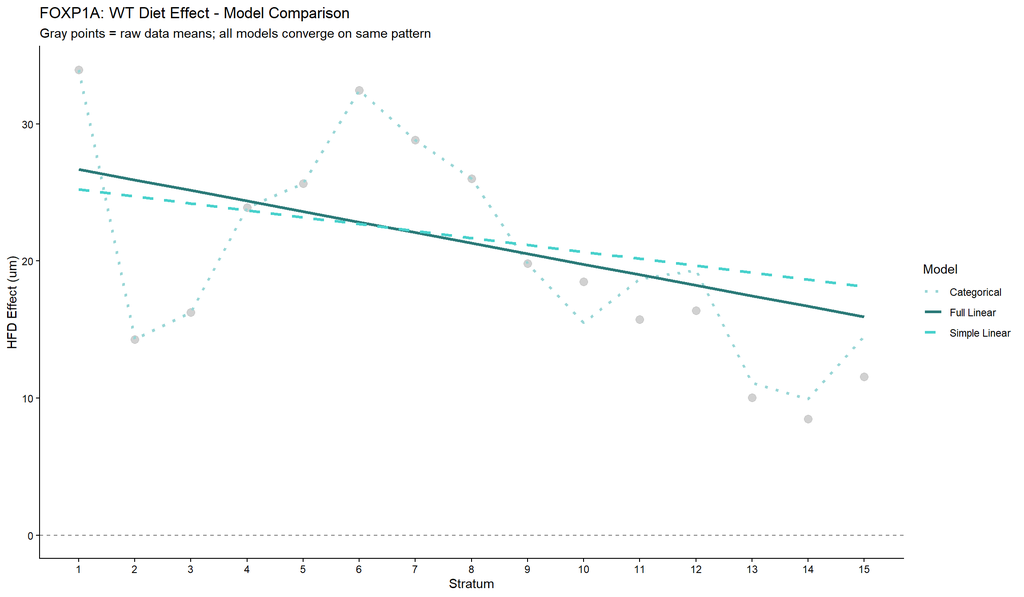

```r
# Extract WT diet effects from all models
emm_full_a <- emmeans(model_full_a, pairwise ~ Diet | Genotype + Stratum_numeric,
                      at = list(Stratum_numeric = 1:15))
emm_simple_a <- emmeans(model_simple_a, pairwise ~ Diet | Genotype + Stratum_numeric,
                        at = list(Stratum_numeric = 1:15))
emm_cat_a <- emmeans(model_cat_a, pairwise ~ Diet | Genotype + Stratum_factor)

con_full_a <- summary(emm_full_a$contrasts)
con_simple_a <- summary(emm_simple_a$contrasts)
con_cat_a <- summary(emm_cat_a$contrasts)

wt_full_a <- con_full_a[con_full_a$Genotype == "WT", ] %>%
  mutate(Diet_Effect = -estimate, Model = "Full Linear")
wt_simple_a <- con_simple_a[con_simple_a$Genotype == "WT", ] %>%
  mutate(Diet_Effect = -estimate, Model = "Simple Linear")
wt_cat_a <- con_cat_a[con_cat_a$Genotype == "WT", ] %>%
  mutate(Stratum_numeric = as.numeric(as.character(Stratum_factor)),
         Diet_Effect = -estimate, Model = "Categorical")

wt_all_models_a <- bind_rows(
  wt_full_a %>% select(Stratum_numeric, Diet_Effect, Model),
  wt_simple_a %>% select(Stratum_numeric, Diet_Effect, Model),
  wt_cat_a %>% select(Stratum_numeric, Diet_Effect, Model)
)

# Raw data
raw_means_a <- foxp1a_test %>%
  group_by(Genotype, Diet, Stratum_numeric) %>%
  summarise(Mean_Diameter = mean(Mean_Feret, na.rm = TRUE), .groups = 'drop') %>%
  pivot_wider(names_from = Diet, values_from = Mean_Diameter) %>%
  mutate(Diet_Effect = HFD - Control) %>%
  filter(!is.na(Diet_Effect))

wt_raw_a <- raw_means_a %>% filter(Genotype == "WT")

ggplot() +
  geom_hline(yintercept = 0, linetype = "dashed", color = "gray50") +
  geom_point(data = wt_raw_a, aes(x = Stratum_numeric, y = Diet_Effect),
             size = 3, color = "gray70", alpha = 0.6) +
  geom_line(data = wt_all_models_a, aes(x = Stratum_numeric, y = Diet_Effect,
                                        color = Model, linetype = Model), linewidth = 1.2) +
  scale_color_manual(values = c("Full Linear" = "#2B7A78",
                                "Simple Linear" = "#48D1CC",
                                "Categorical" = "#99D6D6")) +
  scale_linetype_manual(values = c("Full Linear" = "solid",
                                   "Simple Linear" = "dashed",
                                   "Categorical" = "dotted")) +
  scale_x_continuous(breaks = 1:15) +
  theme_classic() +
  labs(title = "FOXP1A: WT Diet Effect - Model Comparison",
       subtitle = "Gray points = raw data means; all models converge on same pattern",
       x = "Stratum", y = "HFD Effect (um)")
```

### Model Comparison Summary

**Three-way interaction:** NOT significant (p = 0.536)

All three models converge on consistent effect patterns, validating the Full Linear model approach.

## Summary and Conclusions

### Biological Interpretation

The foxp1a mutation has distinct effects from foxp1b:

1. **Constitutive hypertrophy**: Like foxp1b, baseline lipid droplet size is increased on control diet. However to a much lesser degree and not statistically significant.
2. **Loss of spatial information**: Unlike foxp1b, the mutation **abolishes the normal spatial gradient** of HFD response. WT adipose tissue shows position-dependent responses (mature adipocytes respond more than young), but foxp1a mutants respond uniformly regardless of position.
3. **Functional implications**: This suggests foxp1a is required for **positional identity** or **developmental timing** of metabolic responses in adipose tissue. Without foxp1a, adipocytes cannot distinguish their position/age and respond uniformly to metabolic signals.

# Comparison: foxp1a vs foxp1b

## Summary Table

```r
comparison_table %>%
  kable(caption = "Comparison of foxp1a and foxp1b phenotypes")
```

Comparison of foxp1a and foxp1b phenotypes

| Metric | foxp1a | foxp1b |
| --- | --- | --- |
| Baseline genotype effect (early strata) | ~6 um | ~20 um |
| HFD attenuation vs WT | ~20% | ~61% |
| Significant strata (Mutant diet effect) | 15/15 | 3/15 |
| Significant strata (WT diet effect) | 15/15 | 15/15 |
| Spatial gradient in mutants | Abolished | Preserved |
| Response pattern | Uniform/flat | Transient (early only) |

## Direct Comparison Plot

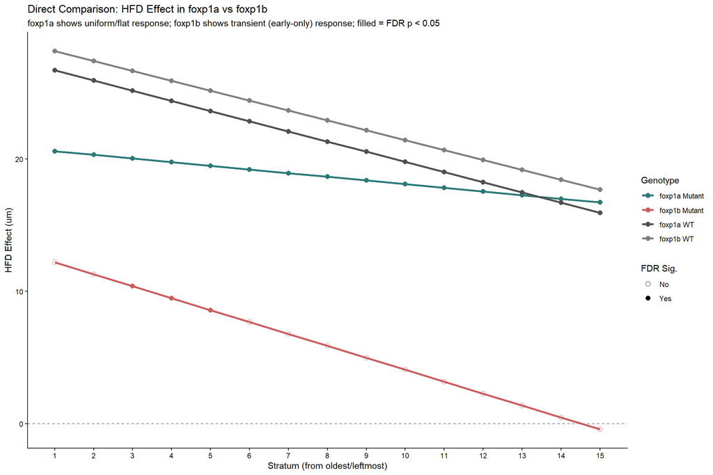

```r
# Combine diet effects from both experiments
diet_effects_comparison <- rbind(
  diet_effects_a %>% mutate(Experiment = "foxp1a"),
  diet_effects_b %>% mutate(Experiment = "foxp1b")
)

ggplot(diet_effects_comparison, aes(x = Stratum_numeric, y = Diet_Effect,
                                     color = interaction(Experiment, Genotype))) +
  geom_hline(yintercept = 0, linetype = "dashed", color = "gray50") +
  geom_line(linewidth = 1.2) +
  geom_point(aes(shape = FDR_Sig), size = 2.5) +
  scale_color_manual(
    values = c("foxp1a.Mutant" = "#2B7A78", "foxp1a.WT" = "#505050",
               "foxp1b.Mutant" = "#CD5C5C", "foxp1b.WT" = "#808080"),
    labels = c("foxp1a.Mutant" = "foxp1a Mutant", "foxp1a.WT" = "foxp1a WT",
               "foxp1b.Mutant" = "foxp1b Mutant", "foxp1b.WT" = "foxp1b WT")
  ) +
  scale_shape_manual(values = c("No" = 1, "Yes" = 16)) +
  scale_x_continuous(breaks = 1:15) +
  theme_classic() +
  labs(title = "Direct Comparison: HFD Effect in foxp1a vs foxp1b",
       subtitle = "foxp1a shows uniform/flat response; foxp1b shows transient (early-only) response; filled = FDR p < 0.05",
       x = "Stratum (from oldest/leftmost)", y = "HFD Effect (um)",
       color = "Genotype", shape = "FDR Sig.")
```

## Biological Conclusions

### Shared phenotypes (foxp1a AND foxp1b)

**Attenuated HFD response** - both mutations reduce the magnitude of dietary adaptation, with foxp1b mutants showing a more severe attentuation

### Distinct phenotypes

| Feature | foxp1a | foxp1b |
| --- | --- | --- |
| **Spatial pattern** | Lost - uniform response | Preserved - graded response |
| **Temporal pattern** | All strata affected equally | Early strata only (transient) |
| **Reversal on HFD** | No | Yes - WT overtakes mutants |
| **Interpretation** | Required for **positional identity** | Required for **sustained response** |

### Model

The foxp1 paralogs seem to coordinate both the **magnitude** (foxp1b) and **spatial organization** (foxp1a) of adaptive metabolic responses in adipose tissue.

# Methodological Notes

## Statistical approach

This analysis uses linear mixed effects models (LMMs) with the following structure:

**Model:** `Mean_Feret ~ Diet x Genotype x Stratum_numeric + (1|Fish_Pair)`

- **Fixed effects:** Diet, Genotype, Stratum (as continuous), and all interactions
- **Random effects:** Fish_Pair to account for the paired design (same fish measured before/after HFD)
- **Post-hoc contrasts:** Estimated marginal means (emmeans) at each stratum

## Multiple testing correction

We perform 15 contrasts per family (one per stratum) for each comparison: - Diet effects within each genotype (2 families x 15 = 30 tests) - Genotype effects within each diet (2 families x 15 = 30 tests)

**Benjamini-Hochberg (FDR) correction** is applied within each family of 15 contrasts to control the false discovery rate. Both nominal and FDR-adjusted p-values are reported in tables; FDR-adjusted significance is used for all figures.

## Limitations and considerations

1. **Random effects structure:** The model includes random intercepts for Fish_Pair but not random slopes for Stratum. This assumes the spatial pattern is similar across fish within each group. A random slope model `(1 + Stratum_numeric | Fish_Pair)` was considered but may be prone to convergence issues with this sample size.
2. **Stratum as numeric vs factor:** We use Stratum_numeric (continuous) in the primary model to test for linear spatial trends. Categorical models (Stratum_factor) are fitted for comparison and yield similar conclusions.
3. **Residual diagnostics:** QQ-plots and residual vs fitted plots (shown in diagnostics sections) indicate approximate normality with no severe heteroscedasticity.
4. **Effect sign convention:** Diet contrasts are computed as Control - HFD by emmeans. To express effects as “HFD effect” (positive = HFD increases size), we negate the estimate: `Diet_Effect = -estimate`.
5. **Multiple testing across test families:** FDR correction is applied within each family of contrasts (diet effects or genotype effects at 15 strata). We do not apply a global correction across all test families, as these address distinct biological questions. The primary conclusions are supported by omnibus F-tests for interactions, which do not require multiple testing correction.

**Data file**: `foxp1_ld_spatial_data_supplementary.csv`  
**Analysis date**: 2026-01-29  
**R Version**: R version 4.5.1 (2025-06-13 ucrt)  
**Key Packages**: lme4 1.1.37, lmerTest 3.1.3, emmeans 2.0.1